# countries

```r
tail(afr, 3)
```

```
## # A tibble: 3 × 25
##   iso3  name  iso2  region sub-r…¹ inter…²  time total…³ ferti…⁴ lifeE…⁵ child…⁶
##   <chr> <chr> <chr> <chr>  <chr>   <chr>   <dbl>   <dbl>   <dbl>   <dbl>   <dbl>
## 1 SYC   Seyc… SC    Africa Sub-Sa… Easter…  2016  9.47e4    2.39    74.3    14.8
## 2 LBY   Libya LY    Africa Northe… <NA>     2016  6.49e6    2.32    72.3    12.8
## 3 ZAF   Sout… ZA    Africa Sub-Sa… Southe…  2016  5.62e7    2.46    63.2    36.2
## # … with 14 more variables: youthFemaleLiteracy <dbl>, youthMaleLiteracy <dbl>,
## #   adultLiteracy <dbl>, GDP_PC <dbl>, accessElectricity <dbl>,
## #   agriculturalLand <dbl>, agricultureTractors <dbl>, cerealProduction <dbl>,
## #   fertilizerHa <dbl>, co2 <dbl>, greenhouseGases <dbl>, co2_PC <dbl>,
## #   pm2.5_35 <dbl>, battleDeaths <dbl>, and abbreviated variable names
## #   ¹`sub-region`, ²`intermediate-region`, ³totalPopulation, ⁴fertilityRate,
## #   ⁵lifeExpectancy, ⁶childMortality
```

```r
cat("Africa's 3 smallest emitters and COD, SOM, and BDI, while the 3 largest were
SYC, LBY, and ZAF.")
```

```
## Africa's 3 smallest emitters and COD, SOM, and BDI, while the 3 largest were
## SYC, LBY, and ZAF.
```

```r
## americas
amr <- cntry[!is.na(cntry$name) &
      !is.na(cntry$time) &
      !is.na(cntry$co2_PC) &
      cntry$region == "Americas" &
      cntry$time == "2016",] %>%
  arrange(co2_PC)
head(amr, 3)
```

```
## # A tibble: 3 × 25
##   iso3  name  iso2  region sub-r…¹ inter…²  time total…³ ferti…⁴ lifeE…⁵ child…⁶
##   <chr> <chr> <chr> <chr>  <chr>   <chr>   <dbl>   <dbl>   <dbl>   <dbl>   <dbl>
## 1 HTI   Haiti HT    Ameri… Latin … Caribb…  2016  1.08e7    3.04    62.9    68.5
## 2 NIC   Nica… NI    Ameri… Latin … Centra…  2016  6.30e6    2.46    73.9    18.7
## 3 HND   Hond… HN    Ameri… Latin … Centra…  2016  9.27e6    2.54    74.7    18.6
## # … with 14 more variables: youthFemaleLiteracy <dbl>, youthMaleLiteracy <dbl>,
## #   adultLiteracy <dbl>, GDP_PC <dbl>, accessElectricity <dbl>,
## #   agriculturalLand <dbl>, agricultureTractors <dbl>, cerealProduction <dbl>,
## #   fertilizerHa <dbl>, co2 <dbl>, greenhouseGases <dbl>, co2_PC <dbl>,
## #   pm2.5_35 <dbl>, battleDeaths <dbl>, and abbreviated variable names
## #   ¹`sub-region`, ²`intermediate-region`, ³totalPopulation, ⁴fertilityRate,
## #   ⁵lifeExpectancy, ⁶childMortality
```

```r
tail(amr, 3)
```

```
## # A tibble: 3 × 25
##   iso3  name  iso2  region sub-r…¹ inter…²  time total…³ ferti…⁴ lifeE…⁵ child…⁶
##   <chr> <chr> <chr> <chr>  <chr>   <chr>   <dbl>   <dbl>   <dbl>   <dbl>   <dbl>
## 1 CAN   Cana… CA    Ameri… Northe… <NA>     2016  3.61e7    1.54    81.9     5.2
## 2 USA   Unit… US    Ameri… Northe… <NA>     2016  3.23e8    1.82    78.5     6.7
## 3 TTO   Trin… TT    Ameri… Latin … Caribb…  2016  1.38e6    1.75    73.1    19.1
## # … with 14 more variables: youthFemaleLiteracy <dbl>, youthMaleLiteracy <dbl>,
## #   adultLiteracy <dbl>, GDP_PC <dbl>, accessElectricity <dbl>,
## #   agriculturalLand <dbl>, agricultureTractors <dbl>, cerealProduction <dbl>,
## #   fertilizerHa <dbl>, co2 <dbl>, greenhouseGases <dbl>, co2_PC <dbl>,
## #   pm2.5_35 <dbl>, battleDeaths <dbl>, and abbreviated variable names
## #   ¹`sub-region`, ²`intermediate-region`, ³totalPopulation, ⁴fertilityRate,
## #   ⁵lifeExpectancy, ⁶childMortality
```

```r
cat("Americas' 3 smallest emitters and HTI, NIC, and HND, while the 3 largest were
CAN, USA, and TTO.")
```

```
## Americas' 3 smallest emitters and HTI, NIC, and HND, while the 3 largest were
## CAN, USA, and TTO.
```

```r
## asia
asi <- cntry[!is.na(cntry$name) &
      !is.na(cntry$time) &
      !is.na(cntry$co2_PC) &
      cntry$region == "Asia" &
      cntry$time == "2016",] %>%
  arrange(co2_PC)
head(asi, 3)
```

```
## # A tibble: 3 × 25
##   iso3  name  iso2  region sub-r…¹ inter…²  time total…³ ferti…⁴ lifeE…⁵ child…⁶
##   <chr> <chr> <chr> <chr>  <chr>   <chr>   <dbl>   <dbl>   <dbl>   <dbl>   <dbl>
## 1 AFG   Afgh… AF    Asia   Southe… <NA>     2016  3.54e7    4.8     63.8    67.6
## 2 NPL   Nepal NP    Asia   Southe… <NA>     2016  2.73e7    2.03    69.8    34.6
## 3 YEM   Yemen YE    Asia   Wester… <NA>     2016  2.72e7    3.99    66.1    56.8
## # … with 14 more variables: youthFemaleLiteracy <dbl>, youthMaleLiteracy <dbl>,
## #   adultLiteracy <dbl>, GDP_PC <dbl>, accessElectricity <dbl>,
## #   agriculturalLand <dbl>, agricultureTractors <dbl>, cerealProduction <dbl>,
## #   fertilizerHa <dbl>, co2 <dbl>, greenhouseGases <dbl>, co2_PC <dbl>,
## #   pm2.5_35 <dbl>, battleDeaths <dbl>, and abbreviated variable names
## #   ¹`sub-region`, ²`intermediate-region`, ³totalPopulation, ⁴fertilityRate,
## #   ⁵lifeExpectancy, ⁶childMortality
```

```r
tail(asi, 3)
```

```
## # A tibble: 3 × 25
##   iso3  name  iso2  region sub-r…¹ inter…²  time total…³ ferti…⁴ lifeE…⁵ child…⁶
##   <chr> <chr> <chr> <chr>  <chr>   <chr>   <dbl>   <dbl>   <dbl>   <dbl>   <dbl>
## 1 BHR   Bahr… BH    Asia   Wester… <NA>     2016 1425791    2.03    76.9     7.4
## 2 KWT   Kuwa… KW    Asia   Wester… <NA>     2016 3956875    2.08    75.2     8.5
## 3 QAT   Qatar QA    Asia   Wester… <NA>     2016 2654374    1.91    79.9     7.5
## # … with 14 more variables: youthFemaleLiteracy <dbl>, youthMaleLiteracy <dbl>,
## #   adultLiteracy <dbl>, GDP_PC <dbl>, accessElectricity <dbl>,
## #   agriculturalLand <dbl>, agricultureTractors <dbl>, cerealProduction <dbl>,
## #   fertilizerHa <dbl>, co2 <dbl>, greenhouseGases <dbl>, co2_PC <dbl>,
## #   pm2.5_35 <dbl>, battleDeaths <dbl>, and abbreviated variable names
## #   ¹`sub-region`, ²`intermediate-region`, ³totalPopulation, ⁴fertilityRate,
## #   ⁵lifeExpectancy, ⁶childMortality
```

```r
cat("Asia's 3 smallest emitters and AFG, NPL, and YEM, while the 3 largest were
BHR, KWT, and QAT.")
```

```
## Asia's 3 smallest emitters and AFG, NPL, and YEM, while the 3 largest were
## BHR, KWT, and QAT.
```

```r
## europe
eur <- cntry[!is.na(cntry$name) &
      !is.na(cntry$time) &
      !is.na(cntry$co2_PC) &
      cntry$region == "Europe" &
      cntry$time == "2016",] %>%
  arrange(co2_PC)
head(eur, 3)
```

```
## # A tibble: 3 × 25
##   iso3  name  iso2  region sub-r…¹ inter…²  time total…³ ferti…⁴ lifeE…⁵ child…⁶
##   <chr> <chr> <chr> <chr>  <chr>   <chr>   <dbl>   <dbl>   <dbl>   <dbl>   <dbl>
## 1 LIE   Liec… LI    Europe Wester… <NA>     2016   37658    1.61    82.3    NA
## 2 ALB   Alba… AL    Europe Southe… <NA>     2016 2876101    1.66    78.2     9.4
## 3 MDA   Mold… MD    Europe Easter… <NA>     2016 2802170    1.26    71.6    15.3
## # … with 14 more variables: youthFemaleLiteracy <dbl>, youthMaleLiteracy <dbl>,
## #   adultLiteracy <dbl>, GDP_PC <dbl>, accessElectricity <dbl>,
## #   agriculturalLand <dbl>, agricultureTractors <dbl>, cerealProduction <dbl>,
## #   fertilizerHa <dbl>, co2 <dbl>, greenhouseGases <dbl>, co2_PC <dbl>,
## #   pm2.5_35 <dbl>, battleDeaths <dbl>, and abbreviated variable names
## #   ¹`sub-region`, ²`intermediate-region`, ³totalPopulation, ⁴fertilityRate,
## #   ⁵lifeExpectancy, ⁶childMortality
```

```r
tail(eur, 3)
```

```
## # A tibble: 3 × 25
##   iso3  name  iso2  region sub-r…¹ inter…²  time total…³ ferti…⁴ lifeE…⁵ child…⁶
##   <chr> <chr> <chr> <chr>  <chr>   <chr>   <dbl>   <dbl>   <dbl>   <dbl>   <dbl>
## 1 FRO   Faro… FO    Europe Northe… <NA>     2016   48173    2.6     82.0    NA
## 2 LUX   Luxe… LU    Europe Wester… <NA>     2016  582014    1.41    82.7     2.9
## 3 GIB   Gibr… GI    Europe Southe… <NA>     2016   33737   NA       NA      NA
## # … with 14 more variables: youthFemaleLiteracy <dbl>, youthMaleLiteracy <dbl>,
## #   adultLiteracy <dbl>, GDP_PC <dbl>, accessElectricity <dbl>,
## #   agriculturalLand <dbl>, agricultureTractors <dbl>, cerealProduction <dbl>,
## #   fertilizerHa <dbl>, co2 <dbl>, greenhouseGases <dbl>, co2_PC <dbl>,
## #   pm2.5_35 <dbl>, battleDeaths <dbl>, and abbreviated variable names
## #   ¹`sub-region`, ²`intermediate-region`, ³totalPopulation, ⁴fertilityRate,
## #   ⁵lifeExpectancy, ⁶childMortality
```

```r
cat("Europe's 3 smallest emitters and LIE, ALB, and MDA, while the 3 largest were
FRO, LUX, and GIB")
```

```
## Europe's 3 smallest emitters and LIE, ALB, and MDA, while the 3 largest were
## FRO, LUX, and GIB
```

```r
# oceania
oce <- cntry[!is.na(cntry$name) &
      !is.na(cntry$time) &
      !is.na(cntry$co2_PC) &
      cntry$region == "Oceania" &
      cntry$time == "2016",] %>%
  arrange(co2_PC)
head(oce, 3)
```

```
## # A tibble: 3 × 25
##   iso3  name  iso2  region sub-r…¹ inter…²  time total…³ ferti…⁴ lifeE…⁵ child…⁶
##   <chr> <chr> <chr> <chr>  <chr>   <chr>   <dbl>   <dbl>   <dbl>   <dbl>   <dbl>
## 1 SLB   Solo… SB    Ocean… Melane… <NA>     2016  619437    4.45    72.4    21.6
## 2 VUT   Vanu… VU    Ocean… Melane… <NA>     2016  278330    3.86    70.0    28
## 3 KIR   Kiri… KI    Ocean… Micron… <NA>     2016  112524    3.65    67.6    55.8
## # … with 14 more variables: youthFemaleLiteracy <dbl>, youthMaleLiteracy <dbl>,
## #   adultLiteracy <dbl>, GDP_PC <dbl>, accessElectricity <dbl>,
## #   agriculturalLand <dbl>, agricultureTractors <dbl>, cerealProduction <dbl>,
## #   fertilizerHa <dbl>, co2 <dbl>, greenhouseGases <dbl>, co2_PC <dbl>,
## #   pm2.5_35 <dbl>, battleDeaths <dbl>, and abbreviated variable names
## #   ¹`sub-region`, ²`intermediate-region`, ³totalPopulation, ⁴fertilityRate,
## #   ⁵lifeExpectancy, ⁶childMortality
```

```r
tail(oce, 3)
```

```
## # A tibble: 3 × 25
##   iso3  name  iso2  region sub-r…¹ inter…²  time total…³ ferti…⁴ lifeE…⁵ child…⁶
##   <chr> <chr> <chr> <chr>  <chr>   <chr>   <dbl>   <dbl>   <dbl>   <dbl>   <dbl>
## 1 PLW   Palau PW    Ocean… Micron… <NA>     2016  1.77e4   NA       NA      19.1
## 2 AUS   Aust… AU    Ocean… Austra… <NA>     2016  2.42e7    1.75    82.4     3.8
## 3 NCL   New … NC    Ocean… Melane… <NA>     2016  2.77e5    2.08    76.9    NA
## # … with 14 more variables: youthFemaleLiteracy <dbl>, youthMaleLiteracy <dbl>,
## #   adultLiteracy <dbl>, GDP_PC <dbl>, accessElectricity <dbl>,
## #   agriculturalLand <dbl>, agricultureTractors <dbl>, cerealProduction <dbl>,
## #   fertilizerHa <dbl>, co2 <dbl>, greenhouseGases <dbl>, co2_PC <dbl>,
## #   pm2.5_35 <dbl>, battleDeaths <dbl>, and abbreviated variable names
## #   ¹`sub-region`, ²`intermediate-region`, ³totalPopulation, ⁴fertilityRate,
## #   ⁵lifeExpectancy, ⁶childMortality
```

```r
cat("Oceania's 3 smallest emitters and SLB, VUT, and KIR, while the 3 largest were
PLW, AUS, and NCL")
```

```
## Oceania's 3 smallest emitters and SLB, VUT, and KIR, while the 3 largest were
## PLW, AUS, and NCL
```

# 4 GDP per capita

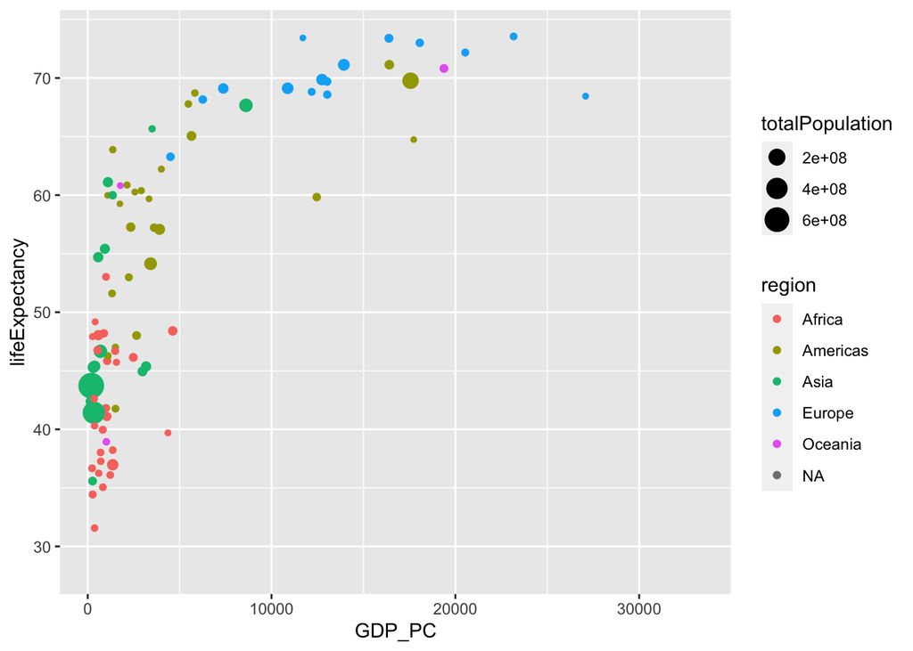

```r
ggplot(data = cntry[cntry$time == 1960,]) +
  geom_point(mapping = aes(x= GDP_PC, y=lifeExpectancy, size = totalPopulation, color=region))
```

2. (4pt) Make a similar plot, but this time use 2019 data only

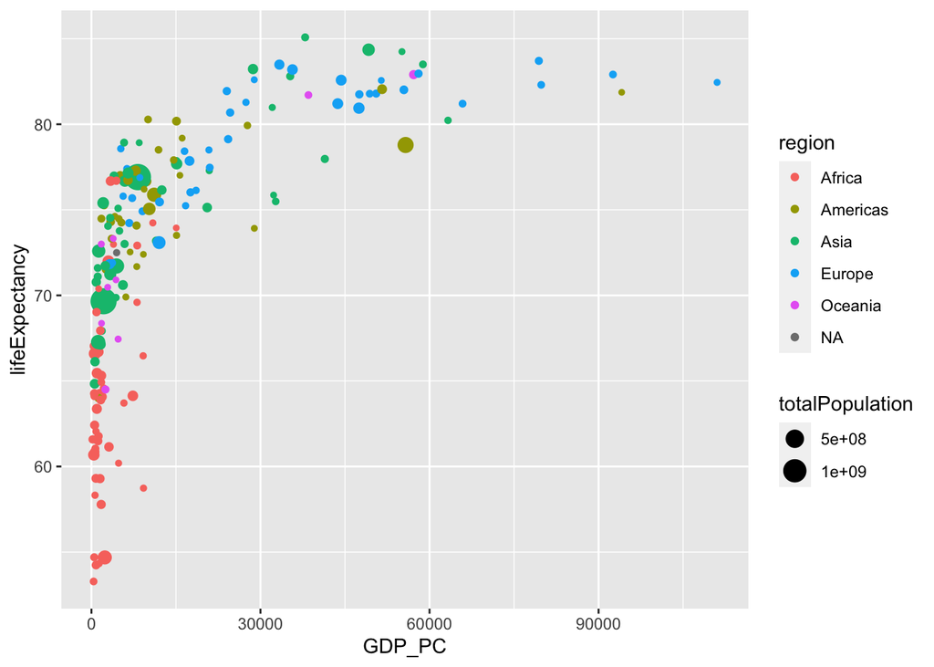

```r
ggplot(data = cntry[cntry$time == 2019,]) +
  geom_point(mapping = aes(x= GDP_PC, y=lifeExpectancy, size = totalPopulation, color=region))
```

3. (6pt) Compare these two plots and comment what do you see. How has world developed through the last 60 years?

```r
LE <- cntry[!is.na(cntry$region) &
            !is.na(cntry$lifeExpectancy) &
            (cntry$time == 1960 | cntry$time == 2019),] %>%
  group_by(region, time) %>%
  summarize(
    avg = sum(lifeExpectancy)/n()
  )
LE
```

```
## # A tibble: 10 × 3
## # Groups:   region [5]
##    region    time   avg
##    <chr>    <dbl> <dbl>
##  1 Africa    1960  41.5
##  2 Africa    2019  64.1
##  3 Americas  1960  58.6
##  4 Americas  2019  75.8
##  5 Asia      1960  51.6
##  6 Asia      2019  74.6
##  7 Europe    1960  68.3
##  8 Europe    2019  79.4
##  9 Oceania   1960  56.4
## 10 Oceania   2019  73.5
```

```r
cat("This table shows that all regions actually increased their life expectancy")
```

```
## This table shows that all regions actually increased their life expectancy
```

5. (8pt) Compute the average LE growth from 1960-2019 across the continents. Show the results in the order of growth. Explain what do you see.

```r
group_by(LE, region) %>%
  summarize(
    change = avg[time == 2019] - avg[time == 1960]
  ) %>%
  arrange(change)
```

```
## # A tibble: 5 × 2
##   region   change
##   <chr>     <dbl>
## 1 Europe     11.1
## 2 Oceania    17.1
## 3 Americas   17.2
## 4 Africa     22.6
## 5 Asia       23.0
```

```r
cat("This table shows that Europe's life expectancy increased the least, while Asia's
increased the most.")
```

```
## This table shows that Europe's life expectancy increased the least, while Asia's
## increased the most.
```

6. (6pt) Show the histogram of GDP per capita for years of 1960 and 2019. Try to put both histograms on the same graph, see how well you can do it!

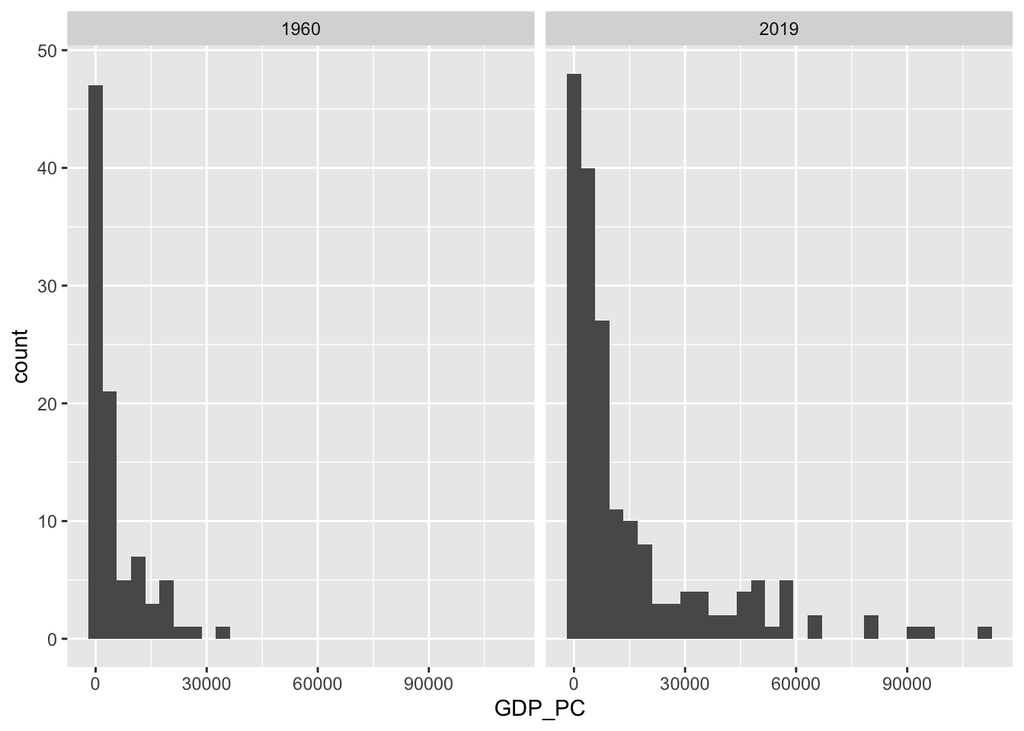

```r
cntry[!is.na(cntry$name) &
      !is.na(cntry$GDP_PC) &
      (cntry$time == 1960 | cntry$time == 2019),] %>%
  ggplot(aes(x = GDP_PC)) +
  geom_histogram(position = "dodge") +
  facet_wrap(~time)
```

7. (6pt) What was the ranking of US in terms of life expectancy in 1960 and in 2019? (When counting from top.)

```r
## 1960
le60 <- cntry[!is.na(cntry$name) &
              !is.na(cntry$lifeExpectancy) &
              (cntry$time == 1960),]

usrank60 <- rank(-(le60$lifeExpectancy), na.last=TRUE, ties.method = "first")[
  which(le60$name == "United States of America")
]

cat("The rank of the US in 1960 was", usrank60)
```

```
## The rank of the US in 1960 was 17
```

```r
## 2019
le19 <- cntry[!is.na(cntry$name) &
              !is.na(cntry$lifeExpectancy) &
              (cntry$time == 2019),]

usrank19 <- rank(-(le19$lifeExpectancy), na.last=TRUE, ties.method = "first")[
  which(le19$name == "United States of America")
]

cat("The rank of the US in 2019 was", usrank19)
```

```
## The rank of the US in 2019 was 46
```

8. (6pt) If you did this correctly, then you noticed that US ranking has been falling quite a bit. But we also have more countries in 2019–what about the relative rank divided by the corresponding number of countries that have LE data in the corresponding year?

relative ranks divided by corresponding number of countries:

1960: 0.0904255

2019: 0.2346939

# Finally tell us how many hours did you spend on this PS.

This PS took me about 6 hours.